# MA 132 Enrollment Model

Tyler Yankee

2022-10-03

## Load data and packages

```r
library(tidyverse)
library(here)
library(janitor)

df = read_csv(here("data_raw", "clarkson_math_enrollment.csv")) %>% clean_names() %>%
  filter(component == "LEC", course_id %in% c(8732, 8733), startsWith(term2, "Fall") | startsWith(term2, "Spring")) %>%
  select(course_id, catalog, term, term2, title, tot_enrl, section) %>%
  distinct()
```

## Examine MA 132 from past years

```r
# Filtering for sum > 0 gets rid of spring 22, we only care about past data
df_ma132_s = df %>% filter(course_id == 8733, startsWith(term2, "Spring")) %>%
  group_by(term2) %>%
  summarise(ma132_s = sum(tot_enrl)) %>%
  filter(ma132_s > 0)
```

## Examine MA 131 in the fall from past years

Some fraction of these students will be going into MA 132 in the following spring, so this is useful data - if nothing else then to visualize.

```r
df_ma131_f = df %>% filter(course_id == 8732, startsWith(term2, "Fall")) %>%
  group_by(term2) %>%
  summarise(ma131_enrl_f = sum(tot_enrl)) %>%
  filter(ma131_enrl_f > 0)
```

## Get MA 132 data

```r
df_ma132_f1 = df %>% filter(course_id == 8733, startsWith(term2, "Fall"), section == 1) %>%
  group_by(term2) %>%
  summarise(ma132_enrl_f1 = sum(tot_enrl)) %>%
  filter(ma132_enrl_f1 > 0)

df_ma132_f23 = df %>% filter(course_id == 8733, startsWith(term2, "Fall"), section == 2 | section == 3) %>%
  group_by(term2) %>%
  summarise(ma132_enrl_f23 = sum(tot_enrl)) %>%
  filter(ma132_enrl_f23 > 0)

df_ma132_s = df %>% filter(course_id == 8733, startsWith(term2, "Spring")) %>%
  group_by(term2) %>%
  summarise(ma132_enrl_s = sum(tot_enrl)) %>%
  filter(ma132_enrl_s > 0)
```

## Assemble data in a table for multiple regression

Bind all previous data together and convert ‘term2’ to a year number, where the year represents the spring of that academic year. For example, the row for “2016” represents 2015 for Fall data and 2016 for Spring data. This approach eliminates the issue of discrepancies between year numbers (i.e., we don’t have Spring 2014 data but do have Fall 2014, since these are from different academic years) and, in general, makes the pairing of fall and spring semesters according to academic year more logical.

```r
# Don't include MA 132 spring data because we need to manipulate the year first
df2 = cbind(df_ma132_f1, df_ma132_f23, df_ma131_f)
df2 <- df2[, !duplicated(colnames(df2), fromLast=TRUE)]

# Note that this makes 'year' a string, if it needs to be an integer we can look at that later.
# I'm only using select() to order the columns here, not actually losing any data
df2 = df2 %>% mutate(year = strtoi(substr(term2, nchar(term2)-4, nchar(term2))) + 1) %>%
  select(year, ma131_enrl_f, ma132_enrl_f1, ma132_enrl_f23)

# Now add the spring data
# Dodging processing the year because we know already that the data is from Spring 2015-2021
# In order to make the rows line up we have to add a 'NA' row for Spring 2022
df_ma132_s = df_ma132_s %>% add_row(term2 = "Spring 2022", ma132_enrl_s = NA)
df2 = cbind(df2, df_ma132_s$ma132_enrl_s)

# Make a separate column for ma132_f combined
df2 = df2 %>% mutate(ma132_enrl_f = ma132_enrl_f1 + ma132_enrl_f23)
```

## Visualizations with df2

```
Warning: Removed 1 rows containing non-finite values (stat_smooth).
Warning: Removed 1 rows containing missing values (geom_point).
```

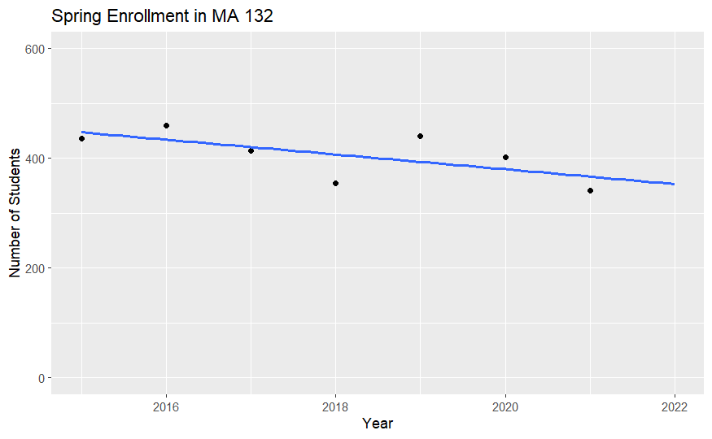

```r
df2 %>% ggplot(aes(x = year, y = df_ma132_s$ma132_enrl_s)) + geom_point() +
  ggtitle("Spring Enrollment in MA 132") + xlab("Year") + ylab("Number of Students") +
  ylim(0, 600) +
  geom_smooth(method = lm, se = FALSE, fullrange = TRUE)
```

```
Warning: Removed 1 rows containing non-finite values (stat_smooth).
Warning: Removed 1 rows containing missing values (geom_point).
```

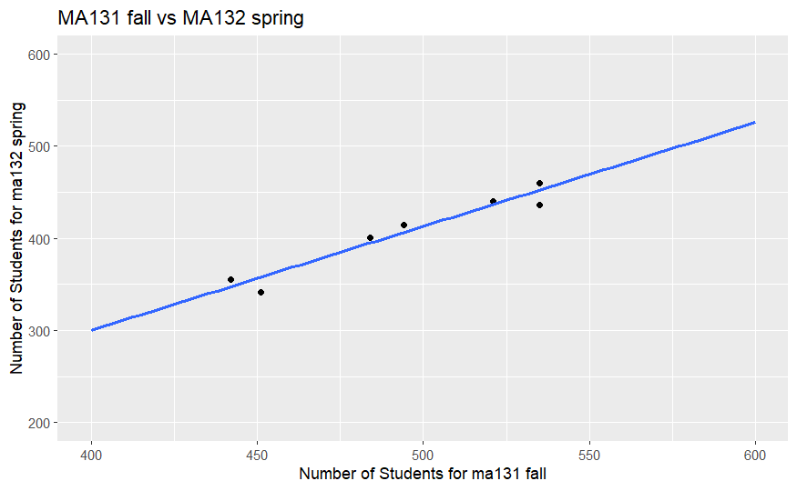

```r
df2 %>% ggplot(aes(x = ma131_enrl_f, y = df_ma132_s$ma132_enrl_s)) + geom_point() +
  ggtitle("MA131 fall vs MA132 spring") +
  xlab("Number of Students for ma131 fall") + ylab("Number of Students for ma132 spring") +
  ylim(200, 600) + xlim(400,600) +
  geom_smooth(method = lm, se = FALSE, fullrange = TRUE)
```

## Predict MA 132 Enrollment w/ Regression

Use multiple linear regression…

```r
lm2 = lm(df_ma132_s$ma132_enrl_s ~ ma131_enrl_f + ma132_enrl_f1 + ma132_enrl_f23, df2)
summary(lm2)
```

```
Call:
lm(formula = df_ma132_s$ma132_enrl_s ~ ma131_enrl_f + ma132_enrl_f1 +
    ma132_enrl_f23, data = df2)

Residuals:
     1      2      3      4      5      6      7
-3.991  7.469 -6.790  7.401 -2.404  7.114 -8.798

Coefficients:
                Estimate Std. Error t value Pr(>|t|)
(Intercept)    -219.0157    66.3421  -3.301  0.04569 *
ma131_enrl_f      1.1147     0.1088  10.243  0.00198 **
ma132_enrl_f1     0.2504     0.4402   0.569  0.60926
ma132_enrl_f23    0.5609     0.2688   2.086  0.12822
---
Signif. codes:  0 ‘***’ 0.001 ‘**’ 0.01 ‘*’ 0.05 ‘.’ 0.1 ‘ ’ 1

Residual standard error: 10.11 on 3 degrees of freedom
  (1 observation deleted due to missingness)
Multiple R-squared:  0.9742,    Adjusted R-squared:  0.9484
F-statistic: 37.79 on 3 and 3 DF,  p-value: 0.006973
```

```r
df3 <- data.frame(ma131_enrl_f = df2[8,"ma131_enrl_f"],
                  ma132_enrl_f1 = df2[8,"ma132_enrl_f1"],
                  ma132_enrl_f23 = df2[8,"ma132_enrl_f23"])
ma132_enrl_s22 = predict(lm2, df3)
sprintf("Prediction for MA 132 Spring 2022 Enrollment: %f", ma132_enrl_s22)
```

```
[1] "Prediction for MA 132 Spring 2022 Enrollment: 356.847608"
```

## Model with one predictor

Only dependent on MA 131 fall enrollment

```r
lm1 = lm(df_ma132_s$ma132_enrl_s ~ ma131_enrl_f, df2)
summary(lm1)
```

```
Call:
lm(formula = df_ma132_s$ma132_enrl_s ~ ma131_enrl_f, data = df2)

Residuals:
      1       2       3       4       5       6       7
-16.297   7.703   7.930   7.559   3.488   6.205 -16.588

Coefficients:
              Estimate Std. Error t value Pr(>|t|)
(Intercept)  -150.9071    65.8443  -2.292 0.070484 .
ma131_enrl_f    1.1275     0.1328   8.490 0.000373 ***
---
Signif. codes:  0 ‘***’ 0.001 ‘**’ 0.01 ‘*’ 0.05 ‘.’ 0.1 ‘ ’ 1

Residual standard error: 12.42 on 5 degrees of freedom
  (1 observation deleted due to missingness)
Multiple R-squared:  0.9351,    Adjusted R-squared:  0.9222
F-statistic: 72.09 on 1 and 5 DF,  p-value: 0.0003726
```

```r
df4 <- data.frame(ma131_enrl_f = df2[8,"ma131_enrl_f"])
ma132_enrl_s22_1 = predict(lm1, df4)
sprintf("Prediction for MA 132 Spring 2022 Enrollment: %f", ma132_enrl_s22_1)
```

```
[1] "Prediction for MA 132 Spring 2022 Enrollment: 364.353102"
```

## Two predictors

Combine the MA 132 fall sections

```r
lm3 = lm(df_ma132_s$ma132_enrl_s ~ ma131_enrl_f + ma132_enrl_f, df2)
summary(lm3)
```

```
Call:
lm(formula = df_ma132_s$ma132_enrl_s ~ ma131_enrl_f + ma132_enrl_f,
    data = df2)

Residuals:
      1       2       3       4       5       6       7
 -3.253   6.807  -5.669  11.004  -0.843   3.130 -11.176

Coefficients:
               Estimate Std. Error t value Pr(>|t|)
(Intercept)  -226.64070   59.95622  -3.780 0.019434 *
ma131_enrl_f    1.12247    0.09944  11.288 0.000351 ***
ma132_enrl_f    0.48067    0.21665   2.219 0.090749 .
---
Signif. codes:  0 ‘***’ 0.001 ‘**’ 0.01 ‘*’ 0.05 ‘.’ 0.1 ‘ ’ 1

Residual standard error: 9.294 on 4 degrees of freedom
  (1 observation deleted due to missingness)
Multiple R-squared:  0.9709,    Adjusted R-squared:  0.9564
F-statistic: 66.78 on 2 and 4 DF,  p-value: 0.0008456
```

```r
df5 <- data.frame(ma131_enrl_f = df2[8,"ma131_enrl_f"],
                  ma132_enrl_f = df2[8,"ma132_enrl_f"])
ma132_enrl_s22_2 = predict(lm3, df5)
sprintf("Prediction for MA 132 Spring 2022 Enrollment: %f", ma132_enrl_s22_2)
```

```
[1] "Prediction for MA 132 Spring 2022 Enrollment: 356.026632"
```

## New Model

After analysis of coefficients Intercept of 0 - if we have zero fall students, we predict 0 spring students

```r
lm4 = lm(df_ma132_s$ma132_enrl_s ~ ma131_enrl_f + ma132_enrl_f + 0, df2)
summary(lm4)
```

```
Call:
lm(formula = df_ma132_s$ma132_enrl_s ~ ma131_enrl_f + ma132_enrl_f +
    0, data = df2)

Residuals:
      1       2       3       4       5       6       7
 -4.226  19.356   6.568  -9.315  10.724   2.077 -30.630

Coefficients:
             Estimate Std. Error t value Pr(>|t|)
ma131_enrl_f  0.81919    0.11234   7.292 0.000759 ***
ma132_enrl_f  0.01441    0.34064   0.042 0.967897
---
Signif. codes:  0 ‘***’ 0.001 ‘**’ 0.01 ‘*’ 0.05 ‘.’ 0.1 ‘ ’ 1

Residual standard error: 17.78 on 5 degrees of freedom
  (1 observation deleted due to missingness)
Multiple R-squared:  0.9986,    Adjusted R-squared:  0.9981
F-statistic:  1848 on 2 and 5 DF,  p-value: 6.704e-08
```

```r
df6 <- data.frame(ma131_enrl_f = df2[8,"ma131_enrl_f"],
                  ma132_enrl_f = df2[8,"ma132_enrl_f"])
ma132_enrl_s22_3 = predict(lm4, df6)
sprintf("Prediction for MA 132 Spring 2022 Enrollment: %f", ma132_enrl_s22_3)
```

```
[1] "Prediction for MA 132 Spring 2022 Enrollment: 376.458991"
```